# Analysis of The President’s Tweets

While not quite a prolific twitter user as say US president Donald Trump, Uhuru Kenyatta is considered a digital president at least that is what he and his team protray him as. Stemming from this i decided to analyse some of his tweets to see if i could find any interesting tidbits or features.

```r
pack <- c("tidytext","tidyverse","rtweet","curl","wordcloud","RColorBrewer")
suppressMessages(lapply(pack,library, character.only=T))
rm(pack)
```

Using the R package Rtweet to access twitter’s API, i obtained 3000 of the president’s tweets and stored them in a csv file. Tabulated below are the first 6 observations from the dataset.

```r
presTweets <- get_timeline("UKenyatta", n= 3000)
presTweets <- janitor::remove_empty_cols(presTweets)
write_csv(presTweets,"presTweets.csv")
rm(presTweets)
```

```r
presTw <- read_csv("presTweets.csv",col_names = TRUE)
presTw <- janitor::remove_empty_cols(presTw)
presTw <- as_tibble(presTw)
head(presTw)
```

| screen_name | user_id | created_at | status_id | text | retweet_count | favorite_count | is_quote_status | quote_status_id | is_retweet | retweet_status_id | in_reply_to_status_user_id | in_reply_to_status_screen_name | lang | source | media_id | media_url | media_url_expanded | urls_display | urls_expanded | mentions_screen_name | mentions_user_id | hashtags |
| --- | --- | --- | --- | --- | --- | --- | --- | --- | --- | --- | --- | --- | --- | --- | --- | --- | --- | --- | --- | --- | --- | --- |
| UKenyatta | 183165874 | 2017-04-18 16:02:54 | 8.543646e+17 | Urged parents to protect their children against being over-exposed to cyber content that could pose dangers to them… https://t.co/mEUfFpadGP | 36 | 76 | FALSE | NA | FALSE | NA | NA | NA | en | Twitter for iPad | NA | NA | NA | twitter.com/i/web/status/8… | https://twitter.com/i/web/status/854364625068019712 | NA | NA | NA |
| UKenyatta | 183165874 | 2017-04-18 15:45:04 | 8.543601e+17 | We have reached a stage in our development where entrepreneurship education for artists must be taught. https://t.co/skbDzU7z1i | 48 | 119 | FALSE | NA | FALSE | NA | NA | NA | en | Twitter for iPad | 8.543601e+17 | http://pbs.twimg.com/media/C9tL_T4XYAAXgdX.jpg | https://twitter.com/UKenyatta/status/854360137443749888/photo/1 | NA | NA | NA | NA | NA |
| UKenyatta | 183165874 | 2017-04-18 15:42:50 | 8.543596e+17 | Delighted to see Kenya’s most talented young people perform. https://t.co/G6wHECh9gz | 40 | 120 | FALSE | NA | FALSE | NA | NA | NA | en | Twitter for iPad | 8.543595e+17 | http://pbs.twimg.com/media/C9tLdGKXsAAUcsO.jpg | https://twitter.com/UKenyatta/status/854359572911448064/photo/1 | NA | NA | NA | NA | NA |
| UKenyatta | 183165874 | 2017-04-18 12:54:55 | 8.543173e+17 | Hosting the 58th edition of the Kenya National Drama Festival State concert at Kisumu State Lodge. https://t.co/4yzoo1ywiB | 105 | 249 | FALSE | NA | FALSE | NA | NA | NA | en | Twitter for iPad | 8.543173e+17 | http://pbs.twimg.com/media/C9slCF9XUAAUHYG.jpg | https://twitter.com/UKenyatta/status/854317317576118274/photo/1 | NA | NA | NA | NA | NA |
| UKenyatta | 183165874 | 2017-04-18 10:56:25 | 8.542875e+17 | Urged the residents to embrace unity and peace and shun leaders who thrive on divisive politics. https://t.co/B1eUYHA4w5 | 81 | 180 | FALSE | NA | FALSE | NA | NA | NA | en | Twitter for iPad | 8.542875e+17 | http://pbs.twimg.com/media/C9sJ7l-WsAECeV-.jpg | https://twitter.com/UKenyatta/status/854287496041181184/photo/1 | NA | NA | NA | NA | NA |
| UKenyatta | 183165874 | 2017-04-18 10:55:20 | 8.542872e+17 | Addressing residents of Kisumu on arrival in the County ahead of the 58th edition of the National Drama Festivals S… https://t.co/Vq59vTygQv | 145 | 295 | FALSE | NA | FALSE | NA | NA | NA | en | Twitter for iPad | NA | NA | NA | twitter.com/i/web/status/8… | https://twitter.com/i/web/status/854287223856013312 | NA | NA | NA |

```r
#Use Pandoc to create tabel?
```

## What hashtags does the president use?

In the first part of this analysis i consider what hashtags the president uses if any at all.

```r
hashtags <- presTw$hashtags %>% unique()
hashtags <- drop_na(hashtags %>% as.data.frame(stringsAsFactors=F))
head(hashtags %>% as_tibble(),8)
```

| value |
| --- |
| JubileeDelivers |
| GoKDelivers JubileeDelivers |
| GoKDelivers |
| IGADSummitOnSomaliRefugees |
| NipasheNaUhuru |
| NipasheNaUhuru StateOfTheNationIsStrong |
| StateOfTheNationIsStrong Uhuru2017 UhuruDeliversResults |
| GoKDELIVERS |

From the table above it is evident that some tweets contain several hashtags. Not quite evident is that hashtags from retweets are included in the hashtags column. As my focus in this case is specifically on hashtags by the president’s account retweet hashtags are excluded.  
To split the hashtags such that there is only one per row I shall use the tidytext package.

```r
Htags <- unnest_tokens(presTw,tags,hashtags,token = "words") %>% filter(!is_retweet==TRUE) %>% select(tags) %>% drop_na() %>% count(tags, sort=T)
colnames(Htags) <- c("Hashtags","Tally")
head(Htags,8)
```

| Hashtags | Tally |
| --- | --- |
| ticadvi | 36 |
| statehousesummit | 15 |
| uhuruinnakuru | 14 |
| tukopamoja | 13 |
| shangiliakenya | 12 |
| uhuruinukambani | 11 |
| afdbam2016 | 10 |
| agrf2016 | 10 |

A better representation of the hashtags used by the president would be a wordcloud.

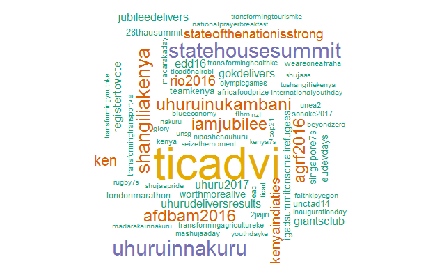

```r
set.seed(1234)
wordcloud(Htags$Hashtags,Htags$Tally,max.words = 100,min.freq = 1,colors = brewer.pal(6,"Dark2"),rot.per = 0.25)
```

## What are the most popular tweets by the president?

To answer this, I shall use two metrics; the favourite count and the retweet count. Plotting a scatter plot it is clear there exists a strong correlation between the two metrics.

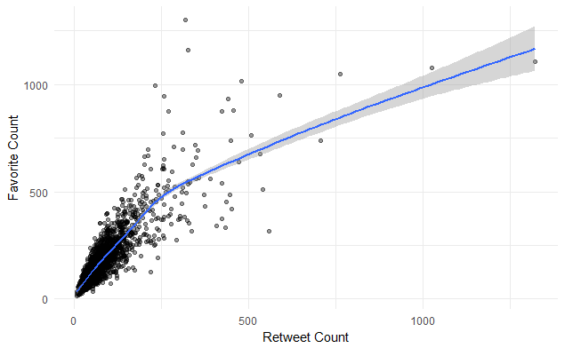

```r
pop <- presTw %>% filter(!is_retweet==TRUE) %>% select(text,favorite_count,retweet_count)
ggplot(pop,aes(retweet_count,favorite_count)) +
  geom_point(alpha=0.40) +
  geom_smooth() +
  labs(x="Retweet Count",y="Favorite Count") +
  theme_minimal()
```

Next i take a look at the distribution of both the retweet count and the favorite count using a histogram. frequency polygon better?

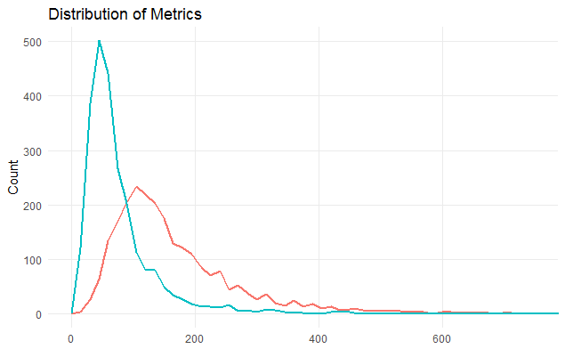

```r
pop1 <- gather(pop,metric,tally,2:3)
ggplot(pop1 , aes(tally,colour= metric)) +
  geom_freqpoly(binwidth=15, size=1) +
  scale_fill_manual(values = c("blue","red")) +
  coord_cartesian(xlim = c(0,750)) +
  labs(x=NULL,y="Count",colour="Metric",title="Distribution of Metrics") +
  theme_minimal() +
  theme(panel.grid.minor = element_blank(),
        legend.position = "none")
```

[figure not shown]

```r
ggplot(pop) +
  geom_histogram(aes(favorite_count),binwidth=15,fill="mediumslateblue",alpha=0.6,colour="slategrey") +
  geom_histogram(aes(retweet_count),binwidth=15,fill="firebrick3",alpha=0.6,colour="slategrey") +
  coord_cartesian(xlim = c(0,750)) +
  labs(x=NULL,y="Count",title="Distribution of Metrics") +
  theme_minimal() +
  annotate("text",x=180,y=365,label="Favorite Count",colour="firebrick3") +
  annotate("text",x=280,y=165,label="Retweet Count",colour="mediumslateblue") +
  theme(panel.grid.major.x = element_blank(),
        panel.grid.minor.x = element_blank()
  )
```

```r
pop2 <- pop %>% arrange(desc(favorite_count),desc(retweet_count))
names(pop2) <- c("Text", "Favorite Count","Retweet Count")
head(pop2,10)
```

| Text | Favorite Count | Retweet Count |
| --- | --- | --- |
| Met India's Prime Minister Narendra Modi at Hyderabad House, New Delhi for bilateral talks. https://t.co/x1y3SxpKDG | 1300 | 318 |
| Formally received in India by President Pranab Mukherjee and PM Narendra Modi at the official residence of the Indi… https://t.co/D4Kglm0HxL | 1159 | 326 |
| #Kenya7s you've done us proud. | 1105 | 1323 |
| Join me in congratulating the Kenya Sevens Rugby Team on their remarkable win against Fiji in the Singapore Sevens Cup rugby finals. | 1077 | 1025 |
| Kenya congratulates Mr Trump for his victorious campaign, and his main opponent, Mrs Hillary Clinton, for her valiant effort. | 1048 | 763 |
| Paid a courtesy call on Former President Daniel arap Moi at his Kabarnet Gardens residence in Nairobi. https://t.co/hYSIiwUdtN | 1015 | 479 |
| Also on scholarships and training opportunities for Kenya's workforce and especially the youth. https://t.co/nz5T64TdL1 | 997 | 232 |
| I won't stop nor be discouraged by the noise and insults peddled by a few individuals because we know that every market has its own mad man. | 950 | 590 |
| Visited the Mahatma Gandhi Memorial Raj Ghat where I laid a wreath in remembrance of the iconic leader of the India… https://t.co/WQWNDjCaQp | 947 | 257 |
| Shared a meal of Nyama Choma with Nairobi leaders at Hayi-Hayi Butchery, Kenyatta Market. https://t.co/4miyO74V6V | 932 | 441 |

```r
rm(pop2)
```

```r
#Remove links from tweets
pop_tidy <- pop
pop_tidy$text <- gsub('http.*\\s*', '', pop_tidy$text)
pop_tidy <- pop_tidy %>% unnest_tokens(word,text) %>% anti_join(stop_words, by="word") %>% count(word,sort=TRUE)
names(pop_tidy) <- c("Word","Tally")
head(pop_tidy,10)
```

| Word | Tally |
| --- | --- |
| kenya | 225 |
| amp | 221 |
| president | 196 |
| county | 188 |
| house | 146 |
| government | 126 |
| residents | 125 |
| development | 120 |
| country | 118 |
| h.e | 112 |

Find an algorithm for stemming the words for a more thorough analysis.

Not surprisingly “Kenya” is the most used word by the President’s twitter page. No doubt that the post referendum period specifically after the 2013 general election the devolved system of government has come to dominate the conversation. Ranking at the fourth most used word by the President.

Yet again its best to visualise this data using a wordcloud.

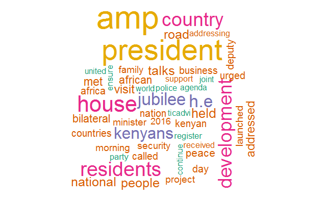

```r
set.seed(1234)
wordcloud(pop_tidy$Word, scale(pop_tidy$Tally, center = T, scale = T),max.words = 100, colors = brewer.pal(6,"Dark2"), min.freq = 3)
```

## Other Questions

- Device used by the president to tweet.
  - Does it have any impact on sentiment of the tweet?
- When(time) does the president tweet?
- Linear regression of fav count and retweet count.
- Does the president use emoji?
  - If so, which is his most used emoji?
  - Are the sentiments in the emoji tweet positive or negative?